# Smartodds

```python
import pandas as pd
import numpy as np
import math
from pandas.core.common import SettingWithCopyWarning
import warnings
import matplotlib.pyplot as plt
import scipy.stats as stats
from scipy.stats import poisson
from scipy.optimize import minimize
import scipy.special
from sklearn.metrics import mean_squared_error, accuracy_score


results = pd.read_csv("USA.csv")

# Ignore the SettingWithCopyWarning warning
warnings.filterwarnings('ignore', category=SettingWithCopyWarning)
warnings.filterwarnings('ignore', category=np.VisibleDeprecationWarning)
warnings.filterwarnings('ignore', category=FutureWarning)
```

## 1. The Data

```python
# Data read in and convert date to datetime format
results['Date'] = pd.to_datetime(results['Date'], format='%d/%m/%Y')
train = results[results['Date']<='2015-12-06']
test = results[(results['Date']>'2015-12-06') & (results['Date']<='2016-10-23')]
```

#### Adding conference data

My method here is to create a dictionairy containing conference data for each season, and then add this to the training dataframe

```python
# Create dataframe containing conference data for 2012-2014
conference_14 = pd.DataFrame()
conference_14[['Team', 'Season']] = [list(np.delete(train['Home'].unique(), np.where((train['Home'].unique() == 'New York City')|(train['Home'].unique() == 'Orlando City' ))))
,2014]
conference_14['Conference'] = ['Western', 'Western', 'Eastern', 'Western', 'Western', 'Western', 'Western', 'Western', 'Eastern', 'Eastern', 'Western', 'Western', 'Eastern', 'Eastern', 'Eastern', 'Eastern', 'Eastern', 'Eastern', 'Eastern']

# Create dataframe containing conference data for 2015 (Houston Dynamo and Sporting Kansas City moved to Western, New York City and Orlando City join Eastern, Chivas USA fold)
conference_15 = conference_14.copy()
conference_15['Season'] = 2015
conference_15.loc[len(conference_15)] = ['New York City', 2015, 'Eastern']
conference_15.loc[len(conference_15)] = ['Orlando City', 2015, 'Eastern']
conference_15.loc[(conference_15['Team'] == 'Houston Dynamo')|(conference_15['Team'] == 'Sporting Kansas City'), 'Conference'] = 'Western'
conference_15 = conference_15.drop(conference_15[conference_15['Team']=='Chivas USA'].index)

# Final dataframe with conference information and season it is true for
conference_df = pd.concat([conference_14, conference_15])

# Create dictionaries for team conferences for each season
team_conferences = {}
for season in range(2012, 2016):
    if season in [2012, 2013, 2014]:
        temp_df = conference_df[conference_df['Season'] == 2014]
    else:
        temp_df = conference_df[conference_df['Season'] == season]
    team_conferences[season] = dict(zip(temp_df['Team'], temp_df['Conference']))

# Add the home_conference and away_conference columns
train['home_conference'] = train.apply(lambda row: team_conferences[row['Season']][row['Home']], axis=1)
train['away_conference'] = train.apply(lambda row: team_conferences[row['Season']][row['Away']], axis=1)
```

## 2. Descriptive Statistics

#### 2.1

The percentage of cross-conference matches is 27.28%. The code to find this is shown below

```python
# The following checks whether the home and away teams are in different conferences for each game and returns either True or False
(train['home_conference'] != train['away_conference']).mean()*100
```

```
27.27935813274982
```

#### 2.2

The value of the 'home advantage' for the Eastern Conference is 0.52, based on the average difference in goals between the home and away team. The equivalent value for the Western Conference is 0.49. I used a 2-sample t-test to test whether there was a statistically significant difference between the Eastern or Western Conference home advantage means. The difference in home advantage between the Eastern and Western Conferences is not statistically significant (p = 0.76).

```python
# Filter the train dataframe to only include matches where both teams belong to the same conference
same_conf_train = train[train['home_conference'] == train['away_conference']]

# Calculate the home advantage for each match in the same conference subset
same_conf_train['home_advantage'] = same_conf_train['HG'] - same_conf_train['AG']

# Calculate the mean home advantage for each conference
eastern_mean = same_conf_train[same_conf_train['home_conference'] == 'Eastern']['home_advantage'].mean()
western_mean = same_conf_train[same_conf_train['home_conference'] == 'Western']['home_advantage'].mean()

# Perform a t-test to determine if the difference between means is statistically significant
t, p = stats.ttest_ind(same_conf_train[same_conf_train['home_conference'] == 'Eastern']['home_advantage'],
                       same_conf_train[same_conf_train['home_conference'] == 'Western']['home_advantage'])

if p < 0.05:
    print(f"The difference in home advantage between the Eastern and Western Conferences is statistically significant (p = {p:.2f})")
else:
    print(f"The difference in home advantage between the Eastern and Western Conferences is not statistically significant (p = {p:.2f})")
```

```
The difference in home advantage between the Eastern and Western Conferences is not statistically significant (p = 0.76)
```

#### 2.3

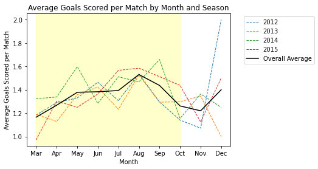

```python
# Create a new column in the train dataframe that contains the month of each match
train['Month'] = pd.DatetimeIndex(train['Date']).month

# Create a new column in the train dataframe that contains the season and month of each match
train['season_month'] = train.apply(lambda x: str(x['Season']) + '_' + str(x['Month']).zfill(2), axis=1)

# Group the data by season and month, and calculate the average number of goals per match
avg_goals_by_season_month = train.groupby(['Season', 'Month'])[['HG', 'AG']].mean().mean(axis=1)

# Calculate the overall average number of goals per match
avg_goals_overall = avg_goals_by_season_month.mean(level='Month')

# Loop through each season and plot the average number of goals scored by month
for season in [2012, 2013, 2014, 2015]:
    season_data = avg_goals_by_season_month.loc[season].reindex([3,4,5,6,7,8,9,10,11,12,1,2])
    plt.plot(list(season_data), label=str(season), linestyle='--', linewidth=1)
avg_goals_by_month = train.groupby('Month')[['HG', 'AG']].mean().mean(axis=1).reindex([3,4,5,6,7,8,9,10,11,12,1,2])
plt.plot(list(avg_goals_by_month), color='k', linestyle='-', linewidth=1.5, label='Overall Average')

# Plot the overall average number of goals per match
plt.title('Average Goals Scored per Match by Month and Season')
plt.xlabel('Month')
plt.ylabel('Average Goals Scored per Match')
plt.xticks([0,1,2,3,4,5,6,7,8,9,10,11], ['Mar', 'Apr', 'May', 'Jun', 'Jul', 'Aug', 'Sep', 'Oct', 'Nov', 'Dec', 'Jan', 'Feb'])
plt.axvspan(0, 7, color='yellow', alpha=0.2)
plt.legend(bbox_to_anchor=(1.05, 1), loc='upper left')
plt.show()
```

The MLS regular season runs from March to October, with playoffs taking place in November and December and then the MLS Cup final. The graph above displays average goals per match by month, with the normal season highlighted in yellow and the playoff season left in white. It shows that average goals per match steadily increase throughout the season, generally peaking in August before dropping just before and during the playoffs. Usually, the MLS cup game is the only game in December, and so we can ignore the uptick at the end of the graph. The low average goals at the start of the season can be explained by teams having lower fitness, experience together, etc at the start of the season making scoring goals more difficult. As the season goes on, and winning games becomes more important as teams fight to make it into the playoffs, goals increase. Additionally, injuries and fatigue may contribute to weaker defences. The drop towards the end of the season could be due to teams playing more cautiously to hold their places in the league, and the drop during playoffs could be due to a change in playing style when the game is a knockout format rather than a league format. The scoring rate across different years is broadly the same.

## 3 A Simple Model

#### 3.1

$\alpha_i$ is the attack score for the home team. $\beta_i$ is the defense score for the home team. $\gamma$ is a constant parameter representing the general scoring rate of the league as a whole. $\eta$ is the 'home advantage' score.

#### 3.2

We need to have constraints on the parameters to make the model identifiable and ensure it has a unique solution. For example, we could make the constraint that $\sum \alpha_i =0$ and $\sum \beta_i =0$, so that they represent the difference in a teams attack and defense compared with the league average, which is represented by the constant $\gamma$. The model assumes that the home and away teams' scoring rates are independent, and that the goals scored by each team in different matches are independent. It also assumes the attack or defense scores are independent of the opponent (e.g. doesn't take into account that teams may defend worse against their local rivals because of added pressure, etc).

#### 3.3

I use Nelder-Mead optimization to maximise the log-likelihood.

```python
nteams = len(train['Home'].unique())

# observed home and away goals for each match
x = train['HG'].values
y = train['AG'].values

# indices of home and away teams for each match
teams = pd.concat([train['Home'], train['Away']])
team_dict = {team: i+1 for i, team in enumerate(teams.unique())}
i = train['Home'].map(team_dict).values
j = train['Away'].map(team_dict).values

# log-likelihood function for the model
def log_likelihood(params):
    alpha = params[:nteams]
    beta = params[nteams:2*nteams]
    gamma, eta = params[2*nteams], params[2*nteams+1]
    lambda_k = np.exp(alpha[i-1] + beta[j-1] + gamma + 0.5*eta)
    mu_k = np.exp(alpha[j-1] + beta[i-1] + gamma - 0.5*eta)
    return np.sum(x*np.log(lambda_k) - lambda_k - np.log(scipy.special.factorial(x)) +
                  y*np.log(mu_k) - mu_k - np.log(scipy.special.factorial(y)))

# initial parameter values
init_params = np.zeros(2*nteams+2)

# optimization using the Nelder-Mead algorithm
result = minimize(lambda params: -log_likelihood(params), init_params, method='Nelder-Mead')

# estimated parameter values
alpha_a = result.x[:nteams]
beta_a = result.x[nteams:2*nteams]
gamma_a, eta_a = result.x[2*nteams], result.x[2*nteams+1]

# compute AIC and BIC for model A
k_a = 2*nteams + 2
n_a = len(train)
aic_a = -2*-result.fun + 2*k_a
bic_a = -2*-result.fun + k_a*np.log(n_a)
lla =  -result.fun

# group data by each team and aggregate goals scored, goals conceded, and games played
team_stats = train.groupby('Home').agg({'HG': 'sum', 'AG': 'sum', 'Away': 'count'}).reset_index()
team_stats.columns = ['Team', 'GoalsScored', 'GoalsConceded', 'GamesPlayed']
team_stats['TeamIndex'] = team_stats['Team'].map(team_dict) # Add team index

# add away goals and games played to the total goals scored and conceded
away_stats = train.groupby('Away').agg({'AG': 'sum', 'HG': 'sum', 'Home': 'count'}).reset_index()
away_stats.columns = ['Team', 'GoalsScored', 'GoalsConceded', 'GamesPlayed']
away_stats['TeamIndex'] = away_stats['Team'].map(team_dict) # Add team index
team_stats = team_stats.merge(away_stats, on='Team')
team_stats['GoalsScored'] = team_stats['GoalsScored_x'] + team_stats['GoalsScored_y']
team_stats['GoalsConceded'] = team_stats['GoalsConceded_x'] + team_stats['GoalsConceded_y']
team_stats['GamesPlayed'] = team_stats['GamesPlayed_x'] + team_stats['GamesPlayed_y']
team_stats = team_stats.drop(['GoalsScored_x', 'GoalsConceded_x', 'GamesPlayed_x', 'GoalsScored_y', 'GoalsConceded_y', 'GamesPlayed_y'], axis=1)

# calculate goals scored and conceded per game
team_stats['GoalsScoredPerGame'] = team_stats['GoalsScored'] / team_stats['GamesPlayed']
team_stats['GoalsConcededPerGame'] = team_stats['GoalsConceded'] / team_stats['GamesPlayed']
team_stats = team_stats.drop('TeamIndex_x', axis=1)
team_stats = team_stats.rename(columns={'TeamIndex_y': 'TeamIndex'})
team_stats = team_stats.sort_values('TeamIndex', ascending=True)
team_stats['alpha'] = alpha_a
team_stats['beta'] = beta_a
team_stats = team_stats.sort_values('alpha', ascending=False)


# print parameter estimates and log-likelihood value
print('gamma:', gamma_a)
print('eta:', eta_a)
print('log-likelihood:', -result.fun)
team_stats.drop(['TeamIndex', 'GoalsScored', 'GoalsConceded', 'GamesPlayed'], axis=1)
```

```
gamma: 0.26806349494492876
eta: 0.3703799907050782
log-likelihood: -3967.191847501438
```

|  | Team | GoalsScoredPerGame | GoalsConcededPerGame | alpha | beta |
| --- | --- | --- | --- | --- | --- |
| 11 | New York Red Bulls | 1.657718 | 1.302013 | 0.199815 | -0.143171 |
| 8 | Los Angeles Galaxy | 1.733333 | 1.206667 | 0.166325 | -0.062322 |
| 17 | Seattle Sounders | 1.460000 | 1.186667 | 0.158817 | -0.195393 |
| 15 | Real Salt Lake | 1.393103 | 1.193103 | 0.150867 | -0.123733 |
| 4 | Columbus Crew | 1.433566 | 1.384615 | 0.120288 | 0.022481 |
| 16 | San Jose Earthquakes | 1.340580 | 1.282609 | 0.112333 | 0.086875 |
| 14 | Portland Timbers | 1.417808 | 1.321918 | 0.109114 | -0.186131 |
| 6 | FC Dallas | 1.440559 | 1.349650 | 0.087481 | 0.026561 |
| 9 | New England Revolution | 1.409722 | 1.298611 | 0.068393 | 0.018936 |
| 20 | Vancouver Whitecaps | 1.264286 | 1.200000 | 0.047947 | -0.193970 |
| 1 | Chicago Fire | 1.299270 | 1.489051 | 0.004168 | 0.068656 |
| 18 | Sporting Kansas City | 1.337931 | 1.055172 | -0.011661 | -0.160135 |
| 13 | Philadelphia Union | 1.264706 | 1.433824 | -0.018620 | -0.040434 |
| 3 | Colorado Rapids | 1.204380 | 1.423358 | -0.034572 | -0.020946 |
| 7 | Houston Dynamo | 1.265306 | 1.367347 | -0.058148 | -0.028226 |
| 19 | Toronto FC | 1.226277 | 1.635036 | -0.073166 | 0.172211 |
| 0 | CF Montreal | 1.335714 | 1.485714 | -0.089226 | 0.158803 |
| 5 | DC United | 1.227586 | 1.344828 | -0.114681 | -0.032315 |
| 12 | Orlando City | 1.352941 | 1.647059 | -0.153102 | -0.069388 |
| 2 | Chivas USA | 0.813725 | 1.823529 | -0.207956 | 0.020211 |
| 10 | New York City | 1.441176 | 1.705882 | -0.245553 | -0.163975 |

## 4 Model Extensions

#### 4.1

Once we have calculated these summary statistics for each team, we can add them as additional predictor variables in the Poisson regression model. We can then estimate the coefficients for these new variables in the Poisson regression model, which will give us an idea of the impact of a team's recent form on their scoring rates. If we want to prioritize interpretability and readability, we can combine these statistics into one 'team form' feature, though it is not clear whether a linear or nonlinear combination would be better, so leaving them as separate statistics is preferable.

In terms of implementation, there would be a couple of issues to address. Firstly, how to deal with filling in these statistics for teams that have not yet played 5 matches. My instinct is to leave the values as zero until they have played 5 games so that, for example, a single large win does not incorrectly give a team a huge 'form' score and give an overly optimstic prediction for their next game. We would also have to accept that this model can only predict games if we have data for the previous 5 matches and so would not be appropriate for some use cases. For example, it would not be appropriate to predict the final league standings before the season has begun, as we would be predicting results using form data that is only based on our model's predictions, not real results. Finally, we would need to evaluate the performance of the model with and without the new predictor variables to see if they improve the model's predictive accuracy.

#### 4.3

- Weather conditions: temperature, wind, speed and precipitation all have an impact on how football is played. Having played for teams since 6 years old, I don't need a model to know that it is both harder to defend and score in the snow, and so I am sure that weather indicators will have a significant relationship with goals scored.
- Team morale/fan sentiment: this is a difficult feature to capture objectively, though some NLP with Twitter data could be useful. I am currently working on a small project classifying tweet sentiment using machine learning, and a similar approach could be used here to generate a feature which could potentially indicate the mental state of the team before each match. This could be useful as it is difficult to incorporate manager changes, player transfers and injuries into the model, though this obviously can have a large impact on results.

#### 4.4

To add seasonality to Model A, we add a parameter, $\omega$, which is a vector of length 10 (the season runs from March to December) in which each element represents the change in scoring rate based on the month. Our new formulas for the log scoring rate are: $\begin{align} \ln\lambda_k &= \alpha_{i(k)} + \beta_{j(k)} + \gamma + \frac{\eta}{2} + \omega_m \\ \ln\mu_k &= \alpha_{j(k)} + \beta_{i(k)} + \gamma - \frac{\eta}{2} + \omega_m \end{align}$ where $\omega_m$ is interpreted as the increase or decrease in scoring rate for that month, with $m \in \{3,...,12\}$. Interpreting the coefficients that we get for $\omega$, the graph below the code helps us to see that they are in line with our intuition. The general pattern of average goals per month is the same as that of the omega values. I used AIC and BIC to evaluate the models. These both penalise extra parameters and evaluate the goodness of fit of a model. Model A had the lower value for both AIC and BIC, and so is the better model.

```
gamma: 0.1958328831402499
eta: 0.3311692054588555
omega: [ 0.00978155 -0.018673    0.1462697   0.13032086  0.09319706  0.19825373
  0.16373619  0.00303368 -0.17340286 -0.15032944]
log-likelihood: -3959.548790603519
```

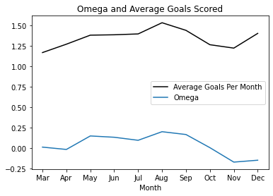

|  | AIC | BIC | log likelihood |
| --- | --- | --- | --- |
| Model A | 8022.383695 | 8252.208705 | -3967.191848 |
| Model B | 8027.097581 | 8309.155548 | -3959.548791 |

```python
# season information for each match
date = train['Date']
month = date.dt.month.values

# log-likelihood function for the model
def log_likelihood(params):
    alpha = params[:nteams]
    beta = params[nteams:2*nteams]
    gamma, eta = params[2*nteams], params[2*nteams+1]
    omega = params[2*nteams+2:2*nteams+12]
    lambda_k = np.exp(alpha[i-1] + beta[j-1] + gamma + eta/2 + omega[month-3])
    mu_k = np.exp(alpha[j-1] + beta[i-1] + gamma - eta/2 + omega[month-3])
    return np.sum(x*np.log(lambda_k) - lambda_k - np.log(scipy.special.factorial(x)) +
                  y*np.log(mu_k) - mu_k - np.log(scipy.special.factorial(y)))

# number of teams and months

nmonths = 10  # March to December

# initial parameter values
init_params = np.zeros(2*nteams+2+nmonths)

# optimization using the Nelder-Mead algorithm
result = minimize(lambda params: -log_likelihood(params), init_params, method='Nelder-Mead')

# estimated parameter values
alpha_b = result.x[:nteams]
beta_b = result.x[nteams:2*nteams]
gamma_b, eta_b = result.x[2*nteams], result.x[2*nteams+1]
omega = result.x[2*nteams+2:2*nteams+12]

# compute AIC and BIC for model B
k_b = 2*nteams + 2 + nmonths
n_b = len(train)
aic_b = -2*-result.fun + 2*k_b
bic_b = -2*-result.fun + k_b*np.log(n_b)
llb =  -result.fun

# print parameter estimates and log-likelihood value
print('gamma:', gamma_b)
print('eta:', eta_b)
print('omega:', omega)
print('log-likelihood:', -result.fun)

# Plot omega
plt.plot(list(avg_goals_by_month), color='k', linestyle='-', linewidth=1.5, label='Average Goals Per Month')
plt.plot(omega, label = 'Omega')
plt.title('Omega and Average Goals Scored')
plt.xlabel('Month')
plt.xticks([0,1,2,3,4,5,6,7,8,9], ['Mar', 'Apr', 'May', 'Jun', 'Jul', 'Aug', 'Sep', 'Oct', 'Nov', 'Dec'])
plt.legend()
plt.show()


comparison_data = {'Model A':[aic_a, bic_a, lla],
                   'Model B':[aic_b, bic_b, llb]}
comparison_table = pd.DataFrame(data=comparison_data, index=['AIC', 'BIC', 'log likelihood']).transpose()
comparison_table.style.set_properties(**{'font-size': '12pt',}).set_table_styles([{'selector':
                                                                                   'th', 'props': [('font-size', '10pt')]}])
comparison_table
```

## 5 Forecasting

#### 5.1

```python
# observed home and away goals for each match in 2016
x_test = test['HG'].values
y_test = test['AG'].values

# indices of home and away teams for each match in 2016 using our team dictionairy
i_test = test['Home'].map(team_dict).values
j_test = test['Away'].map(team_dict).values

# compute scoring rates for each match
lambda_k_test = np.exp(alpha_a[i_test-1] + beta_a[j_test-1] + gamma_a + 0.5*eta_a)
mu_k_test = np.exp(alpha_a[j_test-1] + beta_a[i_test-1] + gamma_a - 0.5*eta_a)
```

#### 5.2

For this section I assumed that no side would score more than 9 goals in a match, and so summed over the potential scorelines given this assumption (e.g. for home wins 1-0, 2-0, 2-1, ..., 9-7, 9-8)

```python
# compute probabilities of home win, draw, and away win
p_hw = []
p_draw = []
p_aw = []
for k in range(len(test)):
    p_home_win = sum([poisson.pmf(x, lambda_k_test[k]) * poisson.pmf(y, mu_k_test[k]) for x in range(1, 10) for y in range(0, x)])
    p_draw_match = sum([poisson.pmf(x, lambda_k_test[k]) * poisson.pmf(x, mu_k_test[k]) for x in range(1, 10)])
    p_away_win = sum([poisson.pmf(x, lambda_k_test[k]) * poisson.pmf(y, mu_k_test[k]) for y in range(1, 10) for x in range(0, y)])
    p_hw.append(p_home_win)
    p_draw.append(p_draw_match)
    p_aw.append(p_away_win)

# create a dataframe with the probabilities
probs_df = pd.DataFrame({'Home win': p_hw, 'Draw': p_draw, 'Away win': p_aw})
```

#### 5.3

```python
# create a dictionary to store the expected points of each team
expected_points = {}
res_preds = []

# loop over all the matches in the test set
for k in range(len(test)):
    home_team = test.iloc[k]['Home']
    away_team = test.iloc[k]['Away']
    lambda_k = lambda_k_test[k]
    mu_k = mu_k_test[k]

    # probability of home win, draw, away win
    p_home_win = probs_df.iloc[k][0]
    p_draw = probs_df.iloc[k][1]
    p_away_win = probs_df.iloc[k][2]

    # assign points based on the outcome of the match
    if p_home_win > p_draw and p_home_win > p_away_win:
        expected_points[home_team] = expected_points.get(home_team, 0) + 3
        res_preds.append('H')

    elif p_draw > p_home_win and p_draw > p_away_win:
        expected_points[home_team] = expected_points.get(home_team, 0) + 1
        expected_points[away_team] = expected_points.get(away_team, 0) + 1
        res_preds.append('D')

    elif p_away_win > p_home_win and p_away_win > p_draw:
        expected_points[away_team] = expected_points.get(away_team, 0) + 3
        res_preds.append('A')


# sort the teams based on their expected points
league_table = sorted(expected_points.items(), key=lambda x: -x[1])

# print the league table
print("League table based on expected points:")
print("Rank\tTeam\t\tExpected Points")
for i, (team, points) in enumerate(league_table):
    print(f"{i+1}\t{team.ljust(20)}\t{points}")
```

```
League table based on expected points:
Rank	Team		Expected Points
1	New York Red Bulls  	75
2	Seattle Sounders    	66
3	Portland Timbers    	57
4	Los Angeles Galaxy  	57
5	Vancouver Whitecaps 	54
6	Real Salt Lake      	54
7	Sporting Kansas City	54
8	FC Dallas           	51
9	San Jose Earthquakes	51
10	New England Revolution	51
11	Colorado Rapids     	51
12	Columbus Crew       	51
13	Philadelphia Union  	51
14	Chicago Fire        	48
15	Houston Dynamo      	45
16	New York City       	45
17	Orlando City        	42
18	CF Montreal         	42
19	DC United           	39
20	Toronto FC          	36
```

#### 5.4

I used the real data from the test set to evaluate the predictive quality of both models. In terms of the predicted expected goals and predicted probabilities my model and Model C are fairly similar. As can be seen in the table below, they have similar accuracy (this is based on the predicted result of the game and the true result of the game) and very similar MSE for both expected home goals and away goals. Overall, Model C has a worse accuracy when it comes to true results of matches but better estimates of the number of goals each team scored in each game.

```python
simset = pd.read_csv('data_mls_simset_predictions.csv')

# create a dictionary to store the expected points of each team and a results prediction list
expected_points = {}
modelC_preds = []

# loop over all the matches in the test set
for k in range(len(test)):
    home_team = test.iloc[k]['Home']
    away_team = test.iloc[k]['Away']
    lambda_k = simset.iloc[k]['expected_team1_goals']
    mu_k =  simset.iloc[k]['expected_team2_goals']

    # probability of home win, draw, away win
    p_home_win = simset.iloc[k]['expected_team1_win']
    p_draw = simset.iloc[k]['expected_draw']
    p_away_win = simset.iloc[k]['expected_team2_win']

    # assign points based on the outcome of the match
    if p_home_win > p_draw and p_home_win > p_away_win:
        expected_points[home_team] = expected_points.get(home_team, 0) + 3
        modelC_preds.append('H')

    elif p_draw > p_home_win and p_draw > p_away_win:
        expected_points[home_team] = expected_points.get(home_team, 0) + 1
        expected_points[away_team] = expected_points.get(away_team, 0) + 1
        modelC_preds.append('D')

    elif p_away_win > p_home_win and p_away_win > p_draw:
        expected_points[away_team] = expected_points.get(away_team, 0) + 3
        modelC_preds.append('A')

# sort the teams based on their expected points
league_table = sorted(expected_points.items(), key=lambda x: -x[1])

# Compute MSE for models' predicted goals
mse_home = mean_squared_error(test['HG'], lambda_k_test)
mse_home_c = mean_squared_error(test['HG'], simset['expected_team1_goals'])
mse_away = mean_squared_error(test['AG'], mu_k_test)
mse_away_c = mean_squared_error(test['AG'], simset['expected_team2_goals'])

# Compute accuracy for results predictions
acc_a = accuracy_score(test['Res'], res_preds)
acc_c = accuracy_score(test['Res'], modelC_preds)

comparison_data = {'Model A':[acc_a, mse_home, mse_away],
                   'Model C':[acc_c, mse_home_c, mse_away_c]}
comparison_table = pd.DataFrame(data=comparison_data, index=['Results Accuracy', 'MSE for Predicted Home Goals', 'MSE for Predicted Away Goals']).transpose()
comparison_table.style.set_properties(**{'font-size': '12pt',}).set_table_styles([{'selector':
                                                                                   'th', 'props': [('font-size', '10pt')]}])
comparison_table
```

|  | Results Accuracy | MSE for Predicted Home Goals | MSE for Predicted Away Goals |
| --- | --- | --- | --- |
| Model A | 0.485294 | 1.558897 | 1.199036 |
| Model C | 0.473529 | 1.476757 | 1.138451 |

## 6 Simulation

#### 6.1

To simulate matches I use np.random.poisson to sample from the Poisson distribution. The parameters are the expected number of goals scored by each team according to my model.

```python
def simulation():
    # create a dictionary to store the expected points of each team
    expected_points = {}
    expected_goals = {}
    expected_diff = {}

    # loop over all the matches in the test set
    for k in range(len(test)):
        home_team = test.iloc[k]['Home']
        away_team = test.iloc[k]['Away']
        lambda_k = lambda_k_test[k]
        mu_k = mu_k_test[k]

        # simulate goals, update goals scored and goal difference
        home_goals = np.random.poisson(lambda_k)
        away_goals = np.random.poisson(mu_k)

        expected_goals[home_team] = expected_goals.get(home_team, 0) + home_goals
        expected_goals[away_team] = expected_goals.get(away_team, 0) + away_goals
        expected_diff[home_team] = expected_diff.get(home_team, 0) + home_goals - away_goals
        expected_diff[away_team] = expected_diff.get(away_team, 0) + away_goals - home_goals

        # update the points for each team based on the match result
        if home_goals > away_goals:
            expected_points[home_team] = expected_points.get(home_team, 0) + 3
        elif home_goals == away_goals:
            expected_points[home_team] = expected_points.get(home_team, 0) + 1
            expected_points[away_team] = expected_points.get(away_team, 0) + 1
        else:
            expected_points[away_team] = expected_points.get(away_team, 0) + 3


    combined_dict = {}
    for key in expected_points.keys():
        combined_dict[key] = {'Expected Points': expected_points[key],
                            'Expected Goal Diff': expected_diff[key],
                            'Expected Goals': expected_goals[key],
                            'Conference': team_conferences[2015][key]}
    simulated_table = pd.DataFrame.from_dict(combined_dict).T.rename_axis('Team').reset_index().sort_values(by=['Expected Points', 'Expected Goal Diff', 'Expected Goals', 'Team'], ascending=[False, False, False, True])
    Eastern_sim = simulated_table[simulated_table['Conference']=='Eastern']
    Western_sim = simulated_table[simulated_table['Conference']=='Western']

    return Western_sim, Eastern_sim

# Single example
pd.concat([simulation()[0], simulation()[1]])
```

|  | Team | Expected Points | Expected Goal Diff | Expected Goals | Conference |
| --- | --- | --- | --- | --- | --- |
| 8 | Portland Timbers | 62 | 18 | 50 | Western |
| 10 | Seattle Sounders | 58 | 15 | 55 | Western |
| 16 | San Jose Earthquakes | 58 | 8 | 46 | Western |
| 14 | Los Angeles Galaxy | 52 | 8 | 44 | Western |
| 18 | Vancouver Whitecaps | 42 | -5 | 41 | Western |
| 3 | Real Salt Lake | 42 | -5 | 38 | Western |
| 4 | FC Dallas | 38 | -12 | 41 | Western |
| 6 | Houston Dynamo | 37 | -14 | 38 | Western |
| 15 | Sporting Kansas City | 35 | -9 | 43 | Western |
| 7 | Colorado Rapids | 34 | -7 | 40 | Western |
| 5 | New England Revolution | 61 | 21 | 58 | Eastern |
| 8 | Columbus Crew | 52 | 8 | 55 | Eastern |
| 17 | Toronto FC | 48 | -2 | 41 | Eastern |
| 16 | New York City | 45 | -5 | 36 | Eastern |
| 0 | New York Red Bulls | 44 | -3 | 41 | Eastern |
| 18 | Philadelphia Union | 42 | -4 | 35 | Eastern |
| 14 | Orlando City | 42 | -6 | 34 | Eastern |
| 13 | DC United | 41 | -10 | 39 | Eastern |
| 1 | Chicago Fire | 35 | -8 | 44 | Eastern |
| 10 | CF Montreal | 31 | -28 | 29 | Eastern |

#### 6.2

Using $10^4$ simulations, LA Galaxy finish in the top 2 of the Western Conference about 27% of the time. The code for this is shown below.

```python
# Simulate 10^4 times
count = 0
for i in range(10**4):
    West = simulation()[0]
    if sum(West[0:2]['Team'] == 'Los Angeles Galaxy')>0:
        count = count + 1
count/10**4
```

```
0.2702
```

#### 6.3

The simulations are all independent and identically distributed, and the probability of LA Galaxy finishing in the top 2 for each simulation is constant (the parameters remain constant for each simulation). The confidence interval is given by $\begin{equation} \hat{p} \pm Z_{0.975}\sqrt{\frac{\hat{p}(1-\hat{p})}{n}} \end{equation}$